### Kornetskyi Yaroslav, Hameliak Yuriy, Marharyta Bilyk

# Loan prediction

## Research Aim

The aim of this research is to explore the factors that influence loan approval in a dataset. The study will primarily focus on variables like Credit History, Income, Marital Status, and Education and their potential impact on the likelihood of loan approval. The research also tests various hypotheses using statistical techniques such as logistic regression, Chi-square tests, and Kolmogorov-Smirnov tests.

## Cleaning and Data Preparation

```r
data <- read.csv("loan_prediction.csv", stringsAsFactors = FALSE)

data[data == ""] <- NA
data <- na.omit(data)

rownames(data) <- data$Loan_ID
data$Loan_ID <- NULL
data$Self_Employed <- data$Self_Employed == "Yes"
data$Loan_Status <- data$Loan_Status == "Y"
data$Married <- data$Married == "Yes"
data$Education <- data$Education == "Graduate"
data$Credit_History <- data$Credit_History == 1

data$Gender <- as.factor(data$Gender)
data$Married <- as.factor(data$Married)
data$Education <- as.factor(data$Education)
data$Self_Employed <- as.factor(data$Self_Employed)
data$Credit_History <- as.factor(data$Credit_History)
data$Property_Area <- as.factor(data$Property_Area)
data$Loan_Status <- as.factor(data$Loan_Status)
data$Dependents <- as.factor(data$Dependents)


head(data, 10)
```

```
##          Gender Married Dependents Education Self_Employed ApplicantIncome
## LP001003   Male    TRUE          1      TRUE         FALSE            4583
## LP001005   Male    TRUE          0      TRUE          TRUE            3000
## LP001006   Male    TRUE          0     FALSE         FALSE            2583
## LP001008   Male   FALSE          0      TRUE         FALSE            6000
## LP001011   Male    TRUE          2      TRUE          TRUE            5417
## LP001013   Male    TRUE          0     FALSE         FALSE            2333
## LP001014   Male    TRUE         3+      TRUE         FALSE            3036
## LP001018   Male    TRUE          2      TRUE         FALSE            4006
## LP001020   Male    TRUE          1      TRUE         FALSE           12841
## LP001024   Male    TRUE          2      TRUE         FALSE            3200
##          CoapplicantIncome LoanAmount Loan_Amount_Term Credit_History
## LP001003              1508        128              360           TRUE
## LP001005                 0         66              360           TRUE
## LP001006              2358        120              360           TRUE
## LP001008                 0        141              360           TRUE
## LP001011              4196        267              360           TRUE
## LP001013              1516         95              360           TRUE
## LP001014              2504        158              360          FALSE
## LP001018              1526        168              360           TRUE
## LP001020             10968        349              360           TRUE
## LP001024               700         70              360           TRUE
##          Property_Area Loan_Status
## LP001003         Rural       FALSE
## LP001005         Urban        TRUE
## LP001006         Urban        TRUE
## LP001008         Urban        TRUE
## LP001011         Urban        TRUE
## LP001013         Urban        TRUE
## LP001014     Semiurban       FALSE
## LP001018         Urban        TRUE
## LP001020     Semiurban       FALSE
## LP001024         Urban        TRUE
```

```r
categorical_columns <- c("Gender", "Married", "Education",
                         "Self_Employed", "Credit_History",
                         "Property_Area", "Loan_Status", "Dependents")
data[categorical_columns] <- lapply(data[categorical_columns], as.factor)

categorical_distributions <- lapply(data[categorical_columns], function(col) {
  prop.table(table(col)) * 100
})
categorical_distributions
```

```
## $Gender
## col
##   Female     Male
## 17.91667 82.08333
##
## $Married
## col
##    FALSE     TRUE
## 35.20833 64.79167
##
## $Education
## col
##    FALSE     TRUE
## 20.20833 79.79167
##
## $Self_Employed
## col
## FALSE  TRUE
## 86.25 13.75
##
## $Credit_History
## col
##    FALSE     TRUE
## 14.58333 85.41667
##
## $Property_Area
## col
##     Rural Semiurban     Urban
##  28.95833  39.79167  31.25000
##
## $Loan_Status
## col
##    FALSE     TRUE
## 30.83333 69.16667
##
## $Dependents
## col
##         0         1         2        3+
## 57.083333 16.666667 17.708333  8.541667
```

## Formulating Assumptions

### For both testing and visual approval:

1. The expected income for male applicants is less than or equal to 6000;
2. `ApplicantIncome` is a significant factor in the likelihood of loan approval;
3. `MaritalStatus` is a significant factor in the likelihood of loan approval;
4. `ApplicantIncome` Distribution is approx. Normal;

### For visual approval only:

4. `LoanAmount` is a significant factor in the likelihood of loan approval;
5. `CreditHistory` is a significant factor in the likelihood of loan approval;

### General assumption

Loan approval can be predicted in general by using information from $1-11$ variables, and we will use them in our custom Naive Bayes classifier and in built-in classifier. Also we will explain the results and accuracy of those two :)

## Testing Assumptions

### Step 1: Hypothesis 1 - `The expected income for male applicants is less than or equal to 6000`

To test this hypothesis, we use a one-sample t-test, which compares the sample mean to a specified value 6000. The test statistic is calculated using the formula:

$$t=\frac{\bar{x}−μ}{s/\sqrt{n}}$$

Where:

- $\bar{x}$: Sample mean
- $\mu$: Population mean (hypothesized mean, 6000 here)
- s: Sample standard deviation
- n: Sample size

**Degrees of freedom (df):**

$$df=n-1$$

To calculate the **p-value**, use the cumulative distribution function (CDF) of the t-distribution:

- For a one-tailed test (greater than $\mu$):

  $$p=1−P(T≤t)$$

We use a one-tailed t-test with the alternative “greater” to determine whether there is enough evidence to reject $H_0$. If the p-value is less than 0.05, we reject $H_0$; otherwise, we fail to reject $H_0$.

```r
male_income <- data$ApplicantIncome[data$Gender == "Male"]
t_test_male_income <- t.test(male_income, mu = 6000, alternative = "greater")

cat("One-sample t-test Results:\n")
```

```
## One-sample t-test Results:
```

```r
t_test_male_income
```

```
##
##  One Sample t-test
##
## data:  male_income
## t = -1.8219, df = 393, p-value = 0.9654
## alternative hypothesis: true mean is greater than 6000
## 95 percent confidence interval:
##  4953.397      Inf
## sample estimates:
## mean of x
##  5450.589
```

```r
if (t_test_male_income$p.value < 0.05) {
  cat("Conclusion: Reject the null hypothesis.")
} else {
  cat("Conclusion: Fail to reject the null hypothesis.")
}
```

```
## Conclusion: Fail to reject the null hypothesis.
```

#### **Restating the Hypotheses**:

- Null Hypothesis ($H_0$): The expected income for male applicants is less than or equal to 6000 (μ ≤ 6000).
- Alternative Hypothesis ($H_1$): The expected income for male applicants is greater than 6000 (μ > 6000).

#### **Test Result Summary**:

- Mean Income of Male Applicants: $5450.589$
- $t_{value}$: $−1.8219$
- $p_{value}$: $0.9654$
- $95$% Confidence Interval : $[4953.397,∞)$

#### **Interpretation**:

Since the $p_{value}$ — $0.9654$ is significantly greater than $0.05$, we fail to reject the null hypothesis ($H_0$). This means there is insufficient statistical evidence to suggest that the expected income for male applicants is greater than $6000$.

The negative $t_{value}$ and the lower bound of the confidence interval further confirm that the mean income is likely below the hypothesized value.

#### **Conclusion**:

The statistical test shows that the average income of male applicants is not greater than 6000. So, we conclude that the data does not provide evidence to support the claim that male applicants’ expected income exceeds the hypothesized threshold.

### Step 2: Hypothesis 2 - `Income vs Loan Approval`

We will use a logistic regression to analyze the relationship between `ApplicantIncome` and `Loan_Status`.

The logistic regression equation is expressed as:

$$logit(p)=ln(\frac{p}{1−p})=β_0+β_1*X$$

Where:

- $p$: Probability of loan approval
- $ln(\frac{p}{1−p})$: Log odds of the outcome
- $β_0$: Intercept
- $β_1$: Coefficient for the predictor variable (X=ApplicantIncome)

The Z-statistic for testing the significance of a predictor is calculated as:

$$Z=\frac{\hat{β}}{SE(\hat{β})}$$

Where:

- $\hat{β}$: Estimated coefficient for the predictor variable.
- $SE(\hat{β})$: Standard error of the coefficient.

To calculate the **p-value**, use the standard normal distribution (Z)

- For a two-tailed test (testing if $β_1≠0$):

  $$p=2⋅(1−P(Z≤∣z∣))$$

  Where $P(Z≤∣z∣)$ is derived from the standard normal distribution.

```r
logit_income <- glm(Loan_Status ~ ApplicantIncome, data = data, family = binomial)
summary(logit_income)
```

```
##
## Call:
## glm(formula = Loan_Status ~ ApplicantIncome, family = binomial,
##     data = data)
##
## Coefficients:
##                   Estimate Std. Error z value Pr(>|z|)
## (Intercept)      8.914e-01  1.347e-01   6.620 3.58e-11 ***
## ApplicantIncome -1.536e-05  1.664e-05  -0.923    0.356
## ---
## Signif. codes:  0 '***' 0.001 '**' 0.01 '*' 0.05 '.' 0.1 ' ' 1
##
## (Dispersion parameter for binomial family taken to be 1)
##
##     Null deviance: 593.05  on 479  degrees of freedom
## Residual deviance: 592.21  on 478  degrees of freedom
## AIC: 596.21
##
## Number of Fisher Scoring iterations: 4
```

#### **Restating the Hypotheses**:

- Null Hypothesis ($H_0$): Applicant’s income has no effect on the likelihood of loan approval.
- Alternative Hypothesis ($H_1$): Higher applicant income increases the likelihood of loan approval.

#### **Test Result Summary**:

- Coefficient for `ApplicantIncome`: $-1.536 \times 10^{-5}$
- $Z_{value}$: $-0.923$
- $p_{value}$: $0.356$

#### **Interpretation**:

Since the $p_{value}$ is greater than $0.05$, we fail to reject the null hypothesis ($H_0$). This means that there is no statistically significant relationship between `ApplicantIncome` and `Loan_Status`.

#### **Conclusion**:

The applicant’s income does not appear to be a significant factor in the likelihood of loan approval, as the statistical test shows no strong association between income and loan approval status.

### Step 3: Hypothesis 3 - `Marital Status vs Loan Approval`

The test statistic is calculated using the formula:

$$χ^{2}=\sum{\frac{(O_i−E_i)^2}{E_i}}$$

Where:

- $O_i$: Observed frequency
- $E_i$ : expected frequency, calculated as:

  $$Ei=\frac{(row_{total})×(column_{total})}
  {grand_{total}}$$

**Degrees of freedom (df):**

$$df=(rows−1)×(columns−1)$$

To calculate the **p-value**, use the CDF of the Chi-Square distribution:

$$p=1−F(χ2;df)$$

Where:

- $F(χ2;df)$: CDF of the Chi-Square distribution for the calculated χ2-statistic with $df$ degrees of freedom.

```r
marital_status_table <- table(data$Married, data$Loan_Status)
chi_test_married <- chisq.test(marital_status_table)
cat("Chi-squared Test Results:\n")
```

```
## Chi-squared Test Results:
```

```r
chi_test_married
```

```
##
##  Pearson's Chi-squared test with Yates' continuity correction
##
## data:  marital_status_table
## X-squared = 5.5571, df = 1, p-value = 0.01841
```

#### **Restating the Hypotheses**:

- Null Hypothesis ($H_0$): Loan approval is independent of the marital status of the applicant.
- Alternative Hypothesis ($H_1$): Married applicants are more likely to have their loans approved.

#### **Test Result Summary**:

- Test statistic ($X^2$): $5.5571$
- Degrees of freedom ($df$): $1$
- $p_{value}$: $0.01841$

#### **Interpretation**:

Since the $p_{value}$ ($0.01841$) is less than $0.05$, we reject the null hypothesis ($H_0$) at a $5%$ significance level. This indicates a statistically significant association between Married and Loan_Status.

#### **Conclusion**

Married applicants are **significantly more likely** to have their loans approved compared to unmarried applicants. Marital status has a meaningful impact on loan approval outcomes.

### Step 4: Kolmogorov-Smirnov Test for Normality of Income

$$D=sup_{x}∣F_n(x)−F(x)∣$$

```r
ks_test_income <- ks.test(data$ApplicantIncome, "pnorm", mean(data$ApplicantIncome), sd(data$ApplicantIncome))
ks_test_income
```

```
##
##  Asymptotic one-sample Kolmogorov-Smirnov test
##
## data:  data$ApplicantIncome
## D = 0.23738, p-value < 2.2e-16
## alternative hypothesis: two-sided
```

#### **Test Result Summary**:

- Test statistic ($D$): $0.23738$
- $p_{value}$: $< 2.2 \times 10^{-16}$

### 1. One-Sample t-Test

The one-sample t-test checks if the average of a sample is different from a specific value. Here, we used it to test if the average income of male applicants is greater than 6000.

#### Why we use the t-Test?

This test works well for continuous data like income when the population’s standard deviation is unknown. It helps us see if the sample mean is significantly different from the hypothesized mean.

**Key Assumptions**:

- The data is continuous and roughly normal.
- Observations are independent.
- The population standard deviation is estimated from the sample.

**Can we replace this test?**

The t-test is the best choice for comparing the mean income of male applicants to a specific value (6000) because it is designed for continuous data and is powerful under normality assumptions. While alternatives exist, they are less powerful or unnecessary unless assumptions are violated. Hence, this **test does not need to be replaced.**

#### 2. Chi-Square Test

The chi-square test is a non-parametric test used to determine if two categorical variables are associated. It is well-suited for hypotheses such as whether Marital Status or Credit History influences loan approval. These variables are categorical, making this test ideal.

**Key Assumptions**:

- Data is in frequency format (counts).
- Observations are independent.
- By applying this test, we assess the independence of variables like Marital Status and their association with Loan Status.

**Can we replace this test?**

The Chi-Square test is ideal for evaluating associations between categorical variables like Marital Status and Loan Status. It handles large datasets effectively and is straightforward to apply. Since alternatives like Fisher’s Exact Test are better suited for small datasets, the Chi-Square test is the best choice here and **does not require replacement**.

#### 3. Logistic Regression

Logistic regression is a statistical model used to understand the relationship between one or more predictor variables and a binary dependent variable. Here, Loan Status is binary (approved or not approved), making logistic regression a logical choice for analyzing relationships with continuous predictors like Applicant Income.

**Why Logistic Regression**?

- Predicts probabilities for a binary outcome.
- Handles continuous and categorical predictors. This test helps evaluate whether higher income or other predictors significantly impact loan approval likelihood.

**Can we replace this test?**

Logistic regression is the standard approach for binary outcomes and can handle continuous and categorical predictors effectively. Its interpretability and robustness make it ideal for understanding predictors’ impact on loan approval. No alternative offers a significant advantage for this purpose, so it remains the best choice.

#### 4. Kolmogorov-Smirnov (KS) Test

**Why Use KS Test**?

- Suitable for continuous variables
- Does not assume normality of the sample. This test helps assess the normality assumption of income data, which is important when choosing statistical methods for further analysis.

**Can we replace this test?**

The KS test compares the income data to a reference distribution and is effective for larger datasets. While other normality tests may offer better sensitivity in specific cases, the KS test is valid and sufficient here. Replacing it is unnecessary unless a more sensitive test is explicitly required.

## Data Visualization

```r
library(ggplot2)
library(moments)
```

### Applicant Income Distribution

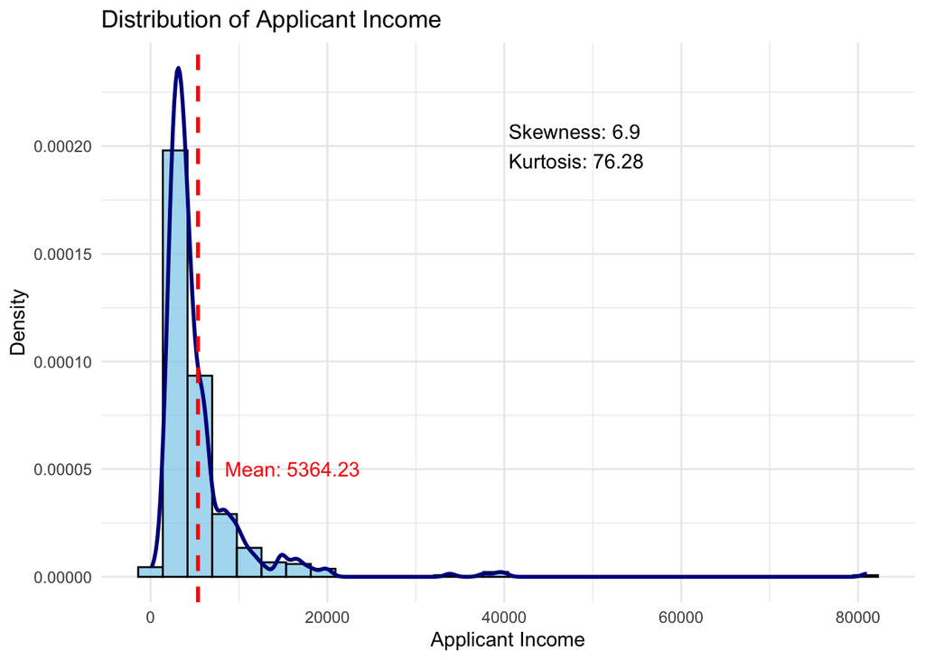

```r
income_skewness <- skewness(data$ApplicantIncome)
income_kurtosis <- kurtosis(data$ApplicantIncome)
income_mean <- mean(data$ApplicantIncome, na.rm = TRUE)

ggplot(data, aes(x = ApplicantIncome)) +
  geom_histogram(aes(y = after_stat(density)), bins = 30, fill = "skyblue", color = "black", alpha = 0.7) +
  geom_density(color = "darkblue", linewidth = 1) +
  geom_vline(xintercept = income_mean, color = "red", linetype = "dashed", linewidth = 1) +
  annotate("text", x = income_mean, y = 0.00005,
           label = paste0("Mean: ", round(income_mean, 2)),
           color = "red", hjust = -0.2) +
  labs(title = "Distribution of Applicant Income",
       x = "Applicant Income",
       y = "Density") +
  annotate("text", x = max(data$ApplicantIncome) * 0.5, y = 0.0002,
           label = paste0("Skewness: ", round(income_skewness, 2),
                          "\nKurtosis: ", round(income_kurtosis, 2)),
           hjust = 0) +
  theme_minimal()
```

**Description**: The data exhibits strong positive skewness (6.9), where the majority of income values are concentrated in the lower range, while a long tail stretches toward higher incomes. The kurtosis value of 76.28 indicates a sharp peak and heavy tails, suggesting the presence of extreme outliers in the income data.

**Conclusions**:

- The skewness and kurtosis values confirm the non-normality of the income distribution. The Kolmogorov-Smirnov (KS) test likely supports this result by rejecting the null hypothesis that the data follows a normal distribution. This insight is crucial for guiding modeling approaches that assume normality in predictors.
- The observed high skewness and extreme outliers help uncover potential biases in loan approvals:
  - Applicants with lower incomes represent the majority, and their approval rates may be disproportionately affected by strict income thresholds or policies.
  - Outliers with significantly high incomes could be influencing overall statistical measures (e.g., mean income), potentially masking patterns within the core applicant group.

### Loan Amount vs. Loan Status

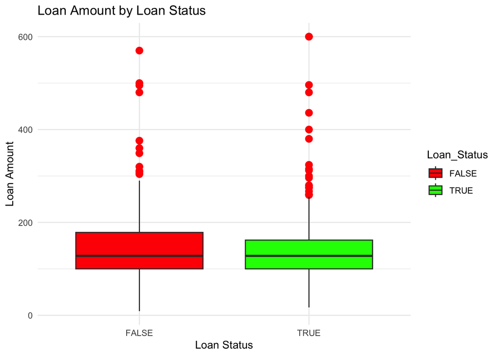

```r
ggplot(data, aes(x = Loan_Status, y = LoanAmount, fill = Loan_Status)) +
  geom_boxplot(outlier.color = "red", outlier.size = 3) +
  scale_fill_manual(values = c("red", "green")) +
  labs(title = "Loan Amount by Loan Status", x = "Loan Status", y = "Loan Amount") +
  theme_minimal()
```

**Conclusions**:

- The overlapping ranges and comparable IQRs suggest that loan amount alone may not be a decisive factor in approval outcomes. Other factors, such as credit history or applicant income, may play a more significant role in the decision process.
- The presence of high-value outliers in both categories indicates that larger loans are sometimes approved and sometimes denied, highlighting inconsistencies or the influence of additional criteria.
- The Kolmogorov-Smirnov (KS) test, if applied, would confirm the non-normality of the loan amount distribution, supporting the need for careful handling of this variable in statistical modeling.
- Logistic regression could further analyze the relationship between loan amount and approval likelihood, accounting for the influence of outliers and other predictors.
- A Chi-Square Test could be used to assess whether loan amounts (categorized into ranges) and loan status are independent, particularly focusing on high-value loans to uncover potential patterns.

### Loan Approval Rates by Marital Status

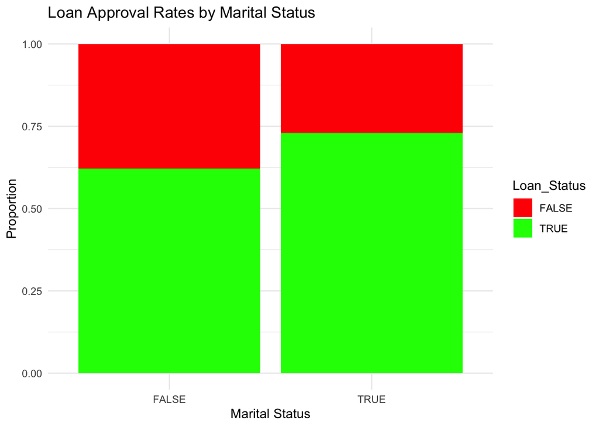

```r
ggplot(data, aes(x = Married, fill = Loan_Status)) +
  geom_bar(position = "fill") +
  scale_fill_manual(values = c("red", "green")) +
  labs(title = "Loan Approval Rates by Marital Status", x = "Marital Status", y = "Proportion") +
  theme_minimal()
```

### Credit History and Loan Status

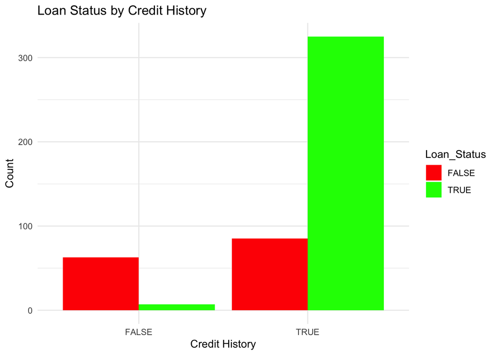

```r
ggplot(data, aes(x = Credit_History, fill = Loan_Status)) +
  geom_bar(position = "dodge") +
  scale_fill_manual(values = c("red", "green")) +
  labs(title = "Loan Status by Credit History", x = "Credit History", y = "Count") +
  theme_minimal()
```

**Description**: The bar chart shows the discrepancy between the two groups highlights a strong relationship between credit history and loan status. Applicants with a positive credit history (TRUE) overwhelmingly receive loan approvals, whereas those without credit history (FALSE) are far more likely to be denied. The discrepancy between the two groups highlights a strong relationship between credit history and loan status.

**Conclusions**:

- This visualization strongly suggests that credit history is a decisive factor in loan approvals. Applicants with positive credit histories are significantly more likely to have their loans approved, whereas those without are predominantly denied.
- A Chi-Square Test can confirm the significant association between credit history and loan status, validating the hypothesis that credit history heavily influences loan decisions.
- Logistic regression would further quantify the impact of credit history on loan approval likelihood, likely showing it as one of the most predictive variables.
- Based on this insight, improving credit history could substantially increase approval rates for applicants, making it a key area for financial guidance and support initiatives.

### Joint Distribution of Applicant and Coapplicant Income

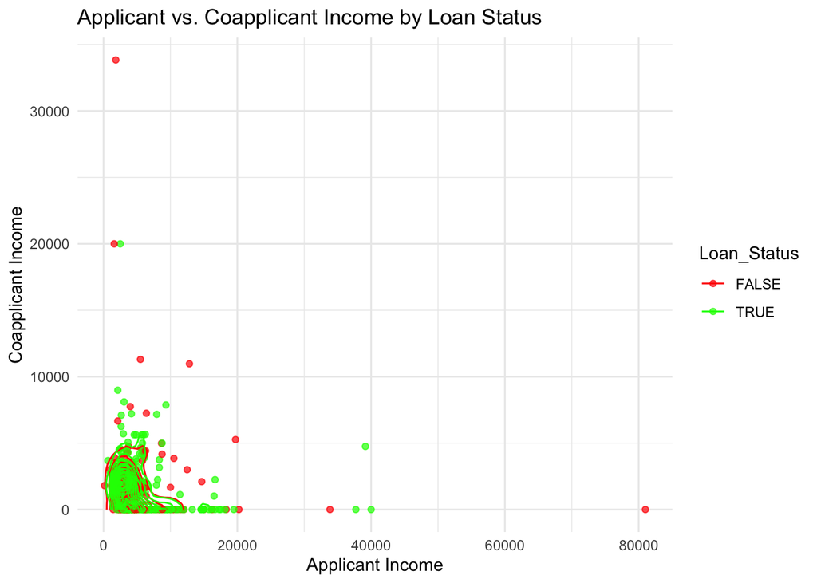

```r
ggplot(data, aes(x = ApplicantIncome, y = CoapplicantIncome, color = Loan_Status)) +
  geom_point(alpha = 0.7) +
  geom_density_2d() +
  scale_color_manual(values = c("red", "green")) +
  labs(title = "Applicant vs. Coapplicant Income by Loan Status",
       x = "Applicant Income", y = "Coapplicant Income") +
  theme_minimal()
```

**Description**: The majority of data points are concentrated near the origin, where either the applicant or coapplicant (or both) have low incomes. Coapplicant incomes are often zero, indicating single-income applications. Approved loans (green) are densely clustered in the lower-income ranges for both applicant and coapplicant incomes, while denied loans (red) are more scattered but still primarily within these ranges. High applicant incomes are rare, and they appear across both approved and denied loans.

**Conclusions**:

- The visualization suggests that low applicant and coapplicant incomes do not necessarily lead to loan denial, as a significant portion of loans in this range are approved. This indicates other factors, such as credit history, may play a more decisive role.
- Coapplicant income appears to have a limited influence on loan outcomes, as approvals occur frequently even when coapplicant income is zero.
- Outliers with high applicant incomes, regardless of loan status, highlight that income alone is not a definitive predictor of approval. Logistic regression could quantify the impact of applicant and coapplicant incomes on approval likelihood.
- The Chi-Square Test could evaluate whether applicant and coapplicant income categories (e.g., low, medium, high) are significantly associated with loan status, while controlling for other factors.
- This scatter plot supports the hypothesis that income interacts with other variables (e.g., credit history) to influence loan decisions, rather than serving as an isolated determinant.

## Classifiers

### Set up data for future testing

```r
set.seed(123)
train_percent <- 50
sample_index <- sample(1:nrow(data), (train_percent / 100) * nrow(data))
train_data <- data[sample_index, ]
test_data <- data[-sample_index, ]
```

### Presets

```r
library(R6) # Just an up-to-date OOP part of R
library(hash) # Just for personal preferences of using hashmaps
library(e1071) # For built-in naive-bayes
# Used for creating so-called bins for values, will be used in custom classifier
get_ranges_from_zero <- function(column) {
  column_range <- range(column, na.rm = TRUE)
  column_range[1] <- 0 # Assure starting from 0

  breaks <- seq(column_range[1], column_range[2], length.out = 20)

  breaks[length(breaks)] <- Inf # Assure ending with inf.

  labels <- paste0(
    "[", head(breaks, -1), ", ",
    ifelse(tail(breaks, -1) == Inf, ">= ", ""), tail(breaks, -1), ")"
  )

  list(breaks = breaks, labels = labels)
}

# Vice versa: gets bin for a value
get_range_for_value <- function(value, ranges) {
  bin <- findInterval(value, ranges$breaks, rightmost.closed = TRUE)
  range_label <- ranges$labels[bin]
  return(range_label)
}
```

### Custom Classifier

#### Classifier build

```r
NaiveBayes <- R6Class(
  "NaiveBayes",
  public = list(
    df_priors = NULL, # Stores prior probabilities for each class
    hash_likelihoods = NULL, # Hashmap for likelihoods of feature values given class
    hash_bins = NULL, # Hashmap for bins of continuous variables

    classes = c(FALSE, TRUE),

    # Used to train model
    fit = function(train_data, target_column) {
      # Extract the target variable and features
      target <- train_data[[target_column]]
      features <- train_data[, setdiff(names(train_data), target_column)]

      # Calculate prior probabilities for each class
      self$df_priors <- data.frame(True = sum(target == TRUE) / length(target),
                                   False = sum(target == FALSE) / length(target))

      self$hash_likelihoods <- hash()

      # Loop through each feature to calculate likelihoods
      for (feature in names(features)) {
        feature_values <- features[[feature]]
        # Handling continuous features
        if (is.numeric(feature_values) & feature != "Loan_Amount_Term") {
          # Determine bin ranges for continuous features
          bin_info <- get_ranges_from_zero(feature_values)
          self$hash_bins[[feature]] <- bin_info

          # Bin it
          binned_values <- cut(
            feature_values,
            breaks = bin_info$breaks,
            labels = bin_info$labels,
            include.lowest = TRUE,
            right = FALSE
          )

          likelihoods <- data.frame(Bin = character(0),
                                    Class = logical(0),
                                    Count = integer(0),
                                    Likelihood = numeric(0))

          # Calculate likelihoods for each class
          for (class in self$classes) {
            likelihood_data <- as.data.frame(table(binned_values, target == class))
            colnames(likelihood_data) <- c("Bin", "Class", "Count")
            likelihood_data$Likelihood <- likelihood_data$Count / sum(likelihood_data$Count)

            # Append likelihood data for this feature and class
            likelihoods <- rbind(likelihoods, likelihood_data)
          }

          self$hash_likelihoods[[feature]] <- likelihoods

        } else { # Handling discrete features
          likelihoods <- data.frame(Value = character(0),
                                    Class = logical(0),
                                    Count = integer(0),
                                    Likelihood = numeric(0))

          # Again, calculate likelihoods for each class
          for (class in self$classes) {
            likelihood_data <- as.data.frame(table(feature_values, target == class))
            colnames(likelihood_data) <- c("Value", "Class", "Count")
            likelihood_data$Likelihood <- likelihood_data$Count / sum(likelihood_data$Count)

            likelihoods <- rbind(likelihoods, likelihood_data)
          }

          # Store the likelihoods in the hashmap
          self$hash_likelihoods[[feature]] <- likelihoods
        }
      }
    },

    # Predict the result for one value
    predict = function(new_data) {
      if (is.null(self$df_priors)) {
        stop("Model has not been trained yet. Please call fit() first.")
      }

      # Start with the prior probabilities as the initial posteriors
      posteriors <- self$df_priors

      for (feature in names(new_data)) {
        feature_value <- new_data[[feature]]

        # Handle continuous features
        if (is.numeric(feature_value) & feature != "Loan_Amount_Term") {

          # Get the bin range for the feature value
          bin_info <- self$hash_bins[[feature]]
          binned_value <- get_range_for_value(feature_value, bin_info)
          likelihood_data <- self$hash_likelihoods[[feature]]

          # Try to retrieve likelihood for the current bin and class, fall back to a small value if not found
          likelihood_false <- tryCatch(
            {
              likelihood_data$Likelihood[likelihood_data$Bin == binned_value & likelihood_data$Class == FALSE]
            },
            error = function(e) {
              1e-4 # Default small likelihood for unseen values
            }
          )
          # Same here
          likelihood_true <- tryCatch(
            {
              likelihood_data$Likelihood[likelihood_data$Bin == binned_value & likelihood_data$Class == TRUE]
            },
            error = function(e) {
              1e-4 # Default small likelihood for unseen values
            }
          )

        } else { # Handle discrete features
          likelihood_data <- self$hash_likelihoods[[feature]]

          # Retrieve likelihoods for the current value and class
          likelihood_true <- likelihood_data$Likelihood[likelihood_data$Value == feature_value & likelihood_data$Class == TRUE]
          likelihood_false <- likelihood_data$Likelihood[likelihood_data$Value == feature_value & likelihood_data$Class == FALSE]
        }

        # Ensuring probabilities are non-zero
        if (length(likelihood_true) == 0) {
          likelihood_true <- 1e-4
        }
        if (length(likelihood_false) == 0) {
          likelihood_false <- 1e-4
        }

        # Update posterior probabilities by multiplying with feature likelihoods
        posteriors$Posterior[posteriors$Class == TRUE] <- posteriors$Posterior[posteriors$Class == TRUE] * likelihood_true
        posteriors$Posterior[posteriors$Class == FALSE] <- posteriors$Posterior[posteriors$Class == FALSE] * likelihood_false
      }

      # Determine the class with the highest posterior probability
      column = names(posteriors[1,])[which.max(posteriors[1,][1, ])]
      return(if (column == "True") TRUE else FALSE)
    },

    # Test the trained model on some data
    test = function(test_data, target_column) {
      target <- test_data[[target_column]]
      features <- test_data[, setdiff(names(test_data), target_column), drop = FALSE]

      predictions <- sapply(1:nrow(features), function(i) {
        new_data <- features[i, , drop = FALSE]
        pred <- self$predict(new_data)
        return(pred)
      })
      accuracy <- mean(predictions == target)
      cat("Accuracy:", round(accuracy * 100, 2), "%\n")
    }
  )
)
```

#### Train Classifier

```r
set.seed(123)
nb_classifier <- NaiveBayes$new()
nb_classifier$fit(train_data, target_column = "Loan_Status")
```

#### Test Classifier Accuracy

```r
nb_classifier$test(train_data, "Loan_Status")
```

```
## Accuracy: 71.67 %
```

### Built-in Classifier

#### Train classifier

```r
model <- naiveBayes(Loan_Status ~ ., data = train_data)
```

#### Test classifier

```r
predictions <- predict(model, test_data)
confusion_matrix <- table(test_data$Loan_Status, predictions)

accuracy <- sum(diag(confusion_matrix)) / sum(confusion_matrix)

cat("Accuracy:", round(accuracy * 100, 2), "%\n")
```

```
## Accuracy: 80.42 %
```

### Why Such Results?

Of course there maybe a lot of different causes of such results, but we can highlight some of the most probable of them. We got $71.67$% for our custom classifier and $80.42$% for the built-in one. It can be result, for instance, of some problems with `binning`. If those `bin`-s aren’t set just right, they might miss important patterns.

But even taking into account these factors it provides us with only $80.42$% accuracy. This can possibly be result of our data preprocessing, where we cleared some not full data. Also it can be result of our training data imbalance ($70$% vs. $30$%, and it is only for loan status). Another possible reason is that it assumes all features are independent, but in reality, that’s rarely true and it may probably hurt performance.

Nonetheless, `v2` (built-in one) still provides us with some not bad predictions, so based on this analysis, we recommend using the built-in model for future predictions, as it delivers better performance and reliability.